# 2024 RA STAT3 Manuscript Analysis

Make a box plot

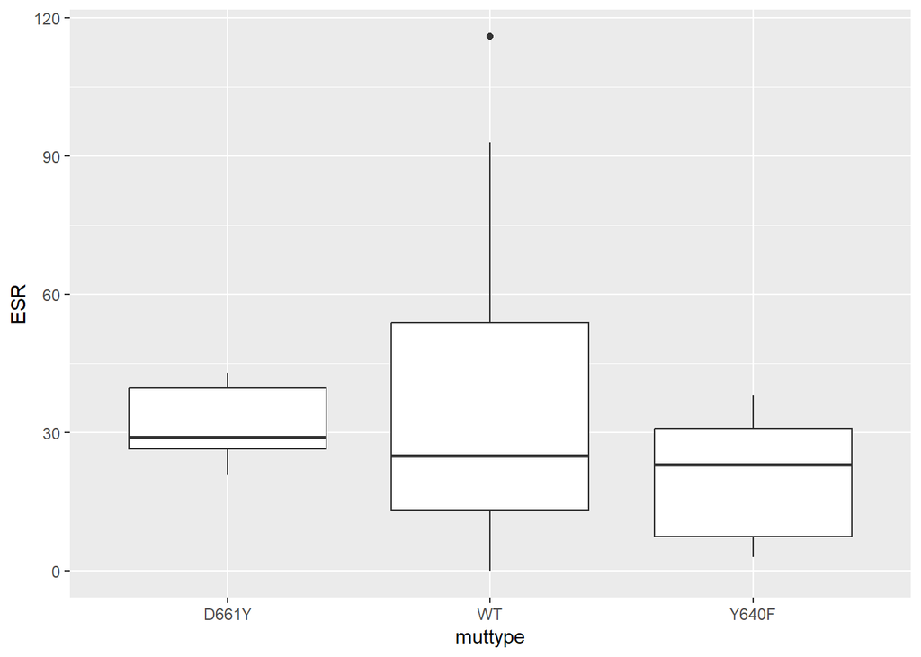

```r
RA3 %>% ggplot(aes(muttype, ESR))+geom_boxplot()
```

```r
#there are zeros, so can't log transform
RA3 %>%
  arrange(ESR) %>%
  select(muttype, ESR)
```

```
## # A tibble: 96 × 2
##    muttype   ESR
##    <chr>   <dbl>
##  1 WT          0
##  2 Y640F       3
##  3 WT          5
##  4 WT          5
##  5 Y640F       6
##  6 WT          7
##  7 WT          7
##  8 WT          7
##  9 WT          8
## 10 WT          9
## # ℹ 86 more rows
```

Run anova in order to test assumptions based on first plot, don’t have equal variance based on second plot, normality is met better than variance ignore the 4th plot

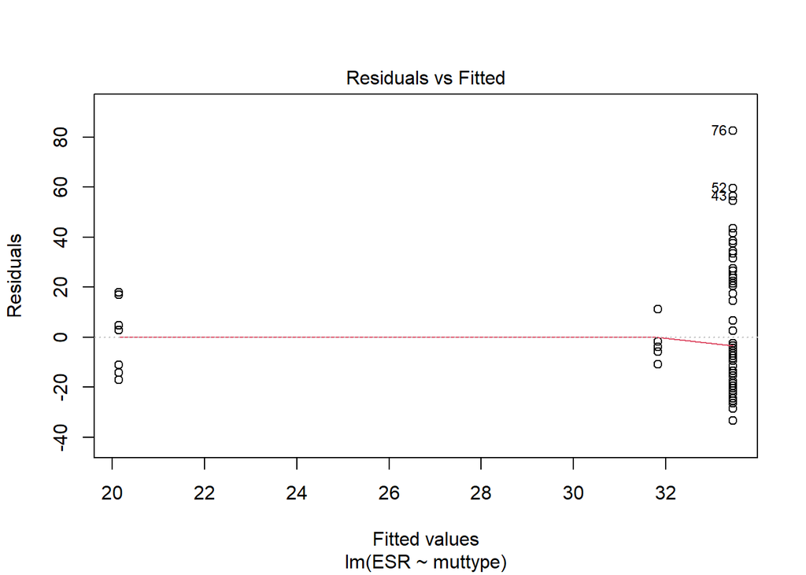

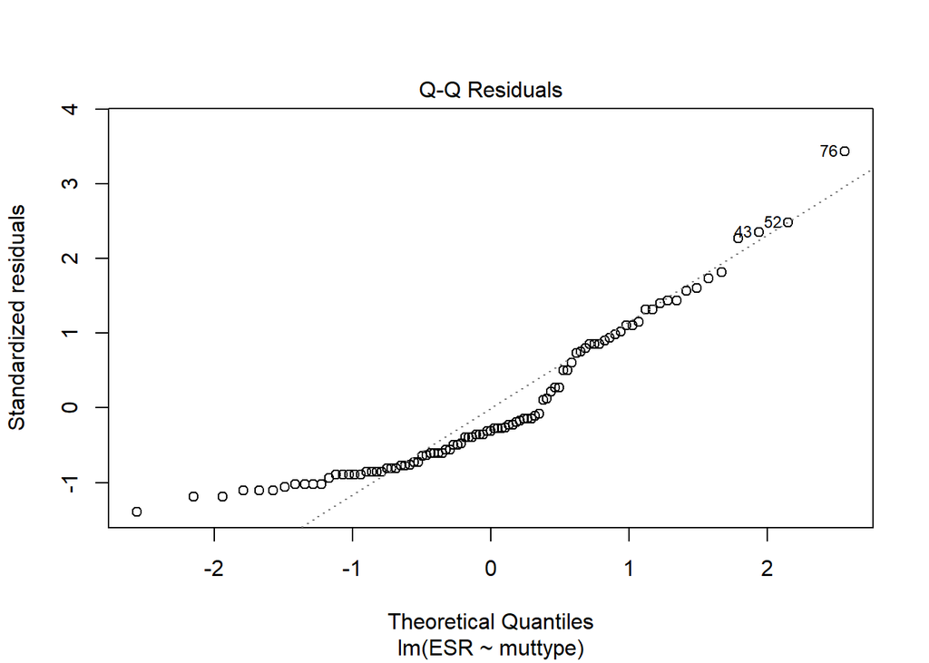

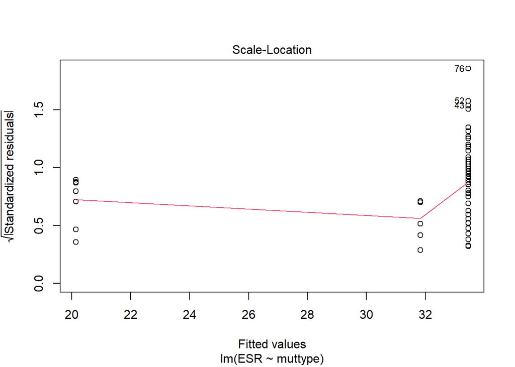

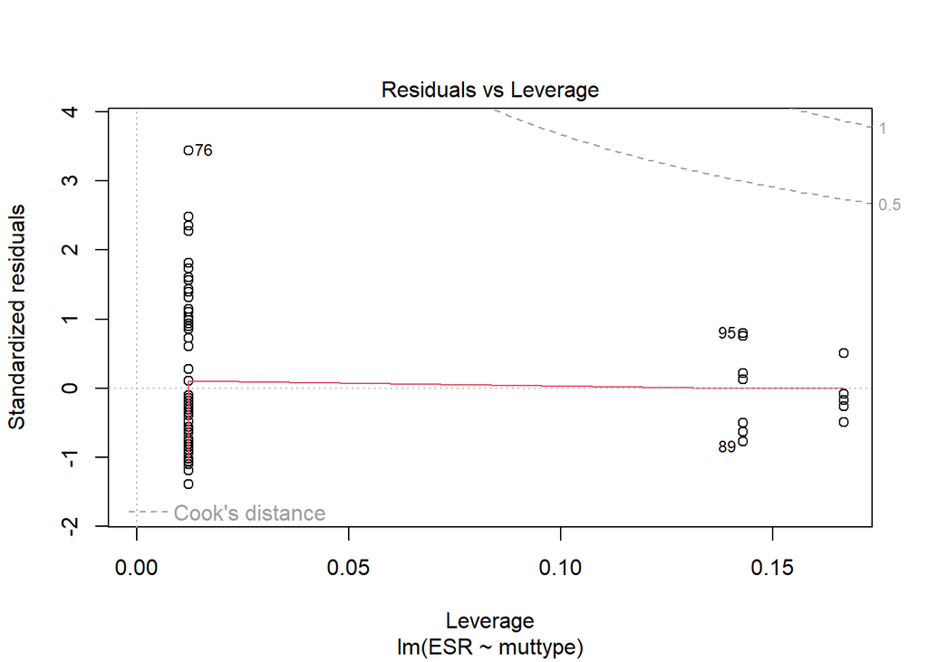

```r
modesr<- lm(ESR~muttype, data = RA3)
plot(modesr)
```

nonequal variance, so welch’s anova

```r
RA3 %>% welch_anova_test(ESR~muttype)
```

```
## # A tibble: 1 × 7
##   .y.       n statistic   DFn   DFd     p method
## * <chr> <int>     <dbl> <dbl> <dbl> <dbl> <chr>
## 1 ESR      96      2.26     2  12.1 0.147 Welch ANOVA
```

```r
RA4 %>% welch_anova_test(ESR~muttypelow)
```

```
## # A tibble: 1 × 7
##   .y.       n statistic   DFn   DFd     p method
## * <chr> <int>     <dbl> <dbl> <dbl> <dbl> <chr>
## 1 ESR      84      1.66     2  33.7 0.205 Welch ANOVA
```

```r
#making a dataset

welch <-
  RA3 %>% welch_anova_test(ESR~muttype) %>%
  rbind(welch)

welch008 <-
  RA4 %>% welch_anova_test(ESR~muttypelow) %>%
  rbind(welch008)
```

### wbc anova

> unequal variance, used welch’s anova, no significance

Make a box plot

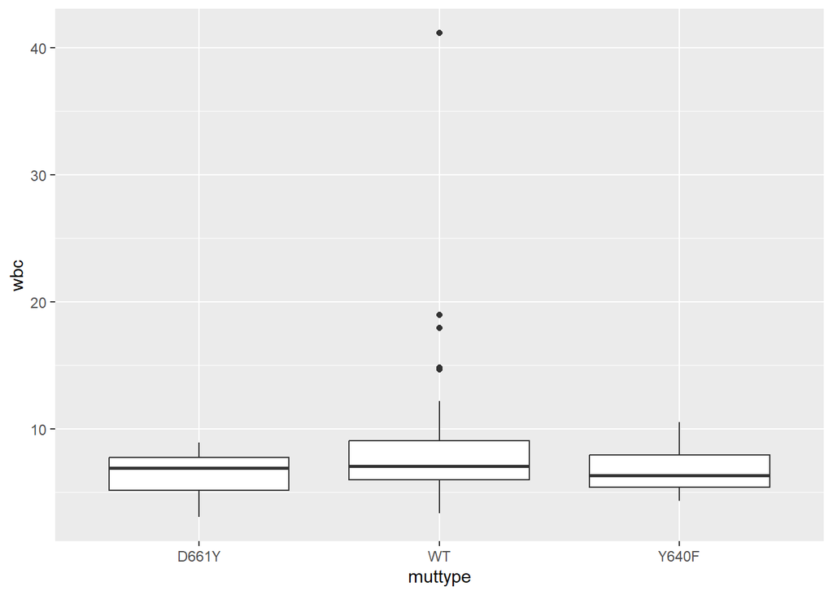

```r
RA3 %>% ggplot(aes(muttype, wbc))+geom_boxplot()
```

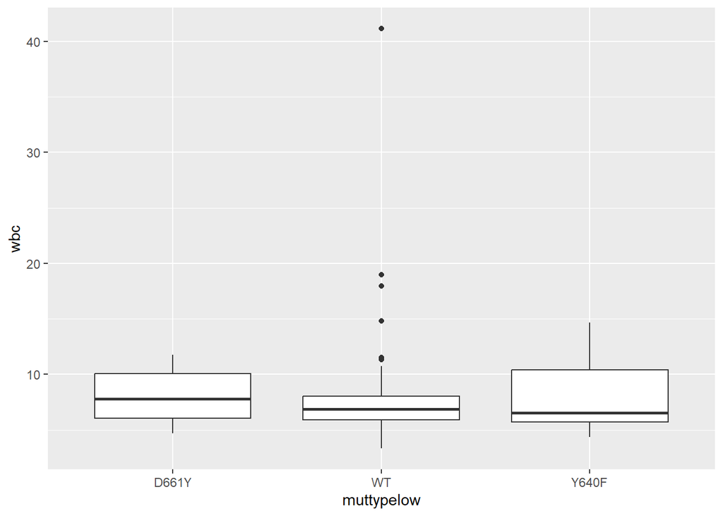

```r
RA4 %>% ggplot(aes(muttypelow, wbc))+geom_boxplot()
```

Run anova in order to test assumptions based on first plot, don’t have equal variance based on second plot, normality is met ignore the 4th plot

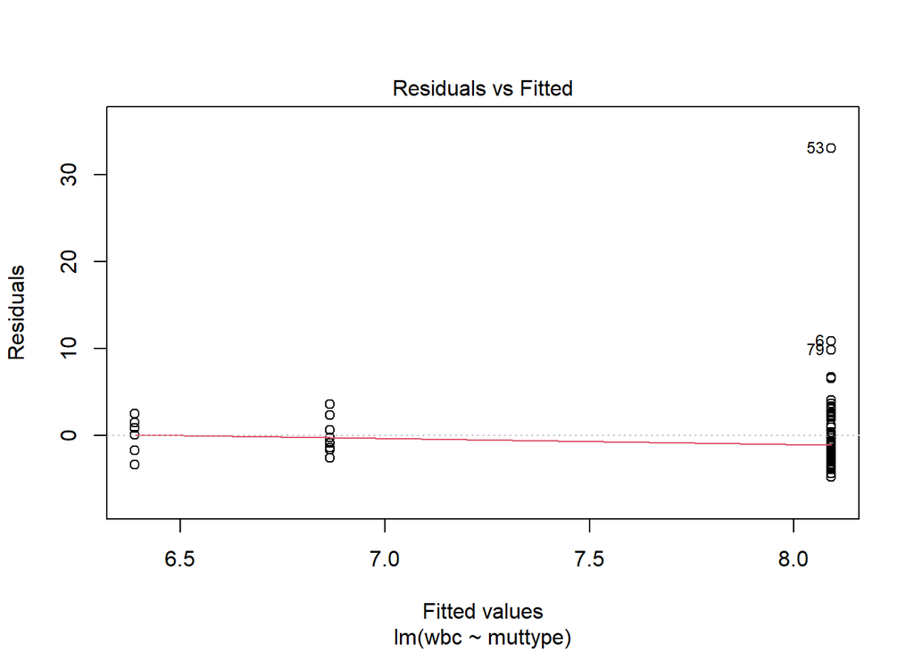

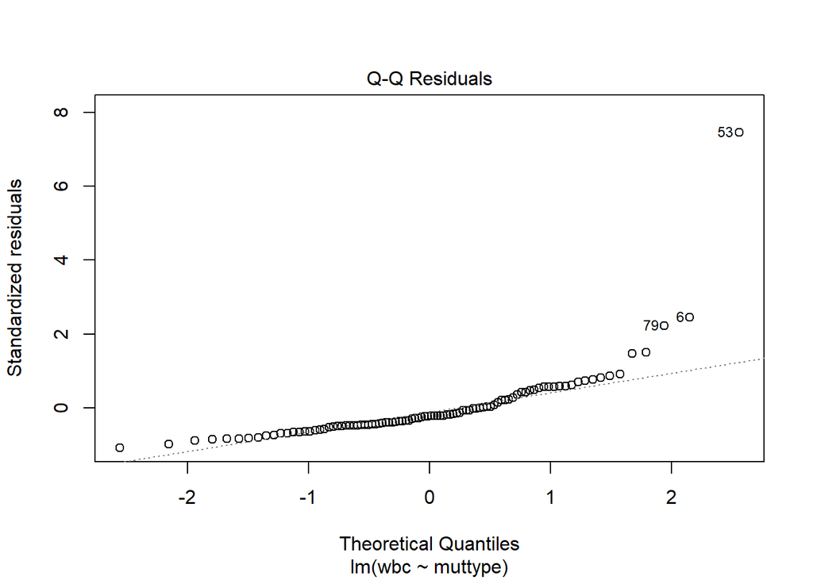

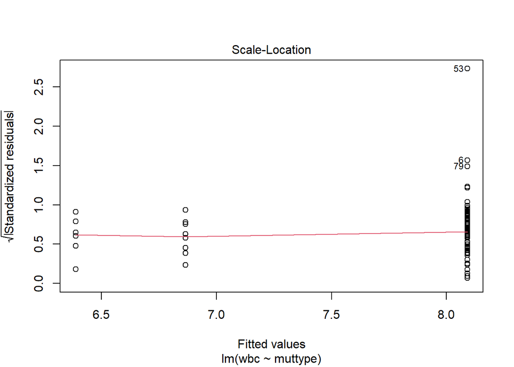

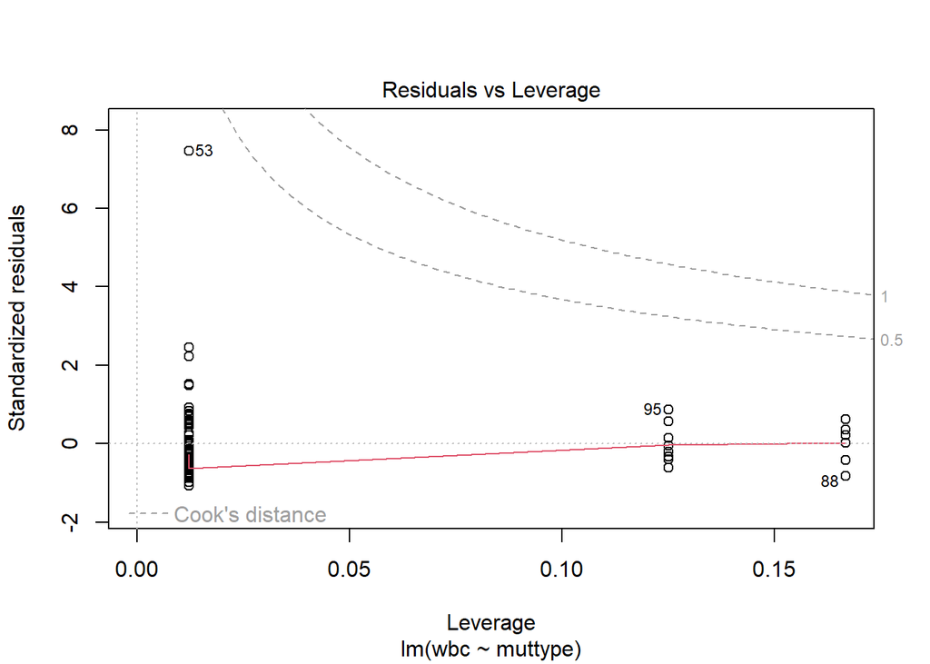

```r
modwbc<- lm(wbc~muttype, data = RA3)
plot(modwbc)
```

nonequal variance, so welch’s anova

```r
RA3 %>% welch_anova_test(wbc~muttype)
```

```
## # A tibble: 1 × 7
##   .y.       n statistic   DFn   DFd     p method
## * <chr> <int>     <dbl> <dbl> <dbl> <dbl> <chr>
## 1 wbc      96      1.69     2  12.6 0.224 Welch ANOVA
```

```r
RA4 %>% welch_anova_test(wbc~muttypelow)
```

```
## # A tibble: 1 × 7
##   .y.       n statistic   DFn   DFd     p method
## * <chr> <int>     <dbl> <dbl> <dbl> <dbl> <chr>
## 1 wbc      84      0.05     2  35.8 0.949 Welch ANOVA
```

```r
#making a dataset
welch <-
  RA3 %>% welch_anova_test(wbc~muttype) %>%
  rbind(welch)

welch008 <-
  RA4 %>% welch_anova_test(wbc~muttypelow) %>%
  rbind(welch008)
```

### ALC anova

> unequal variance, used welch’s anova, no significance

Make a box plot

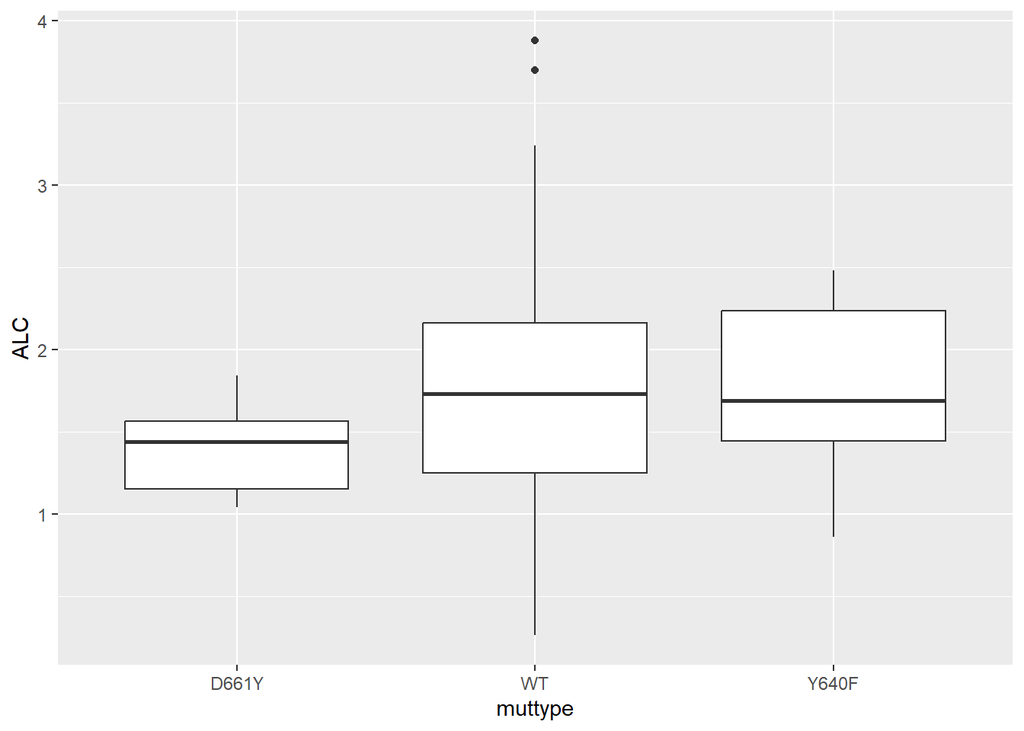

```r
RA3 %>% ggplot(aes(muttype, ALC))+geom_boxplot()
```

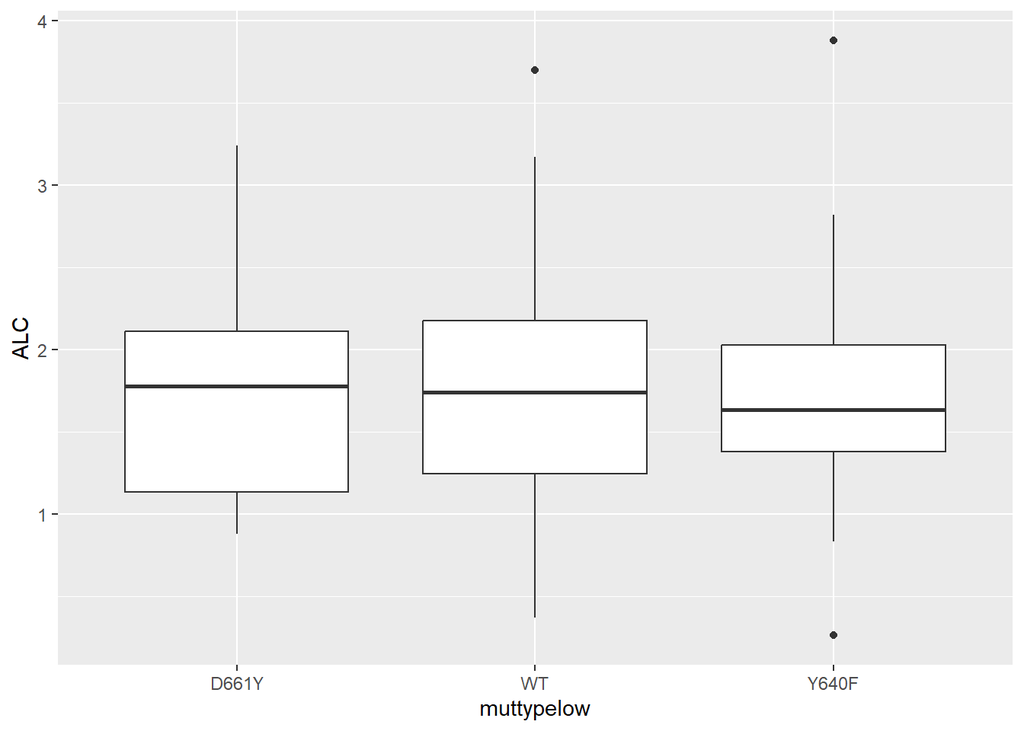

```r
RA4 %>% ggplot(aes(muttypelow, ALC))+geom_boxplot()
```

Run anova in order to test assumptions based on first plot, don’t have equal variance based on second plot, normality is met ignore the 4th plot

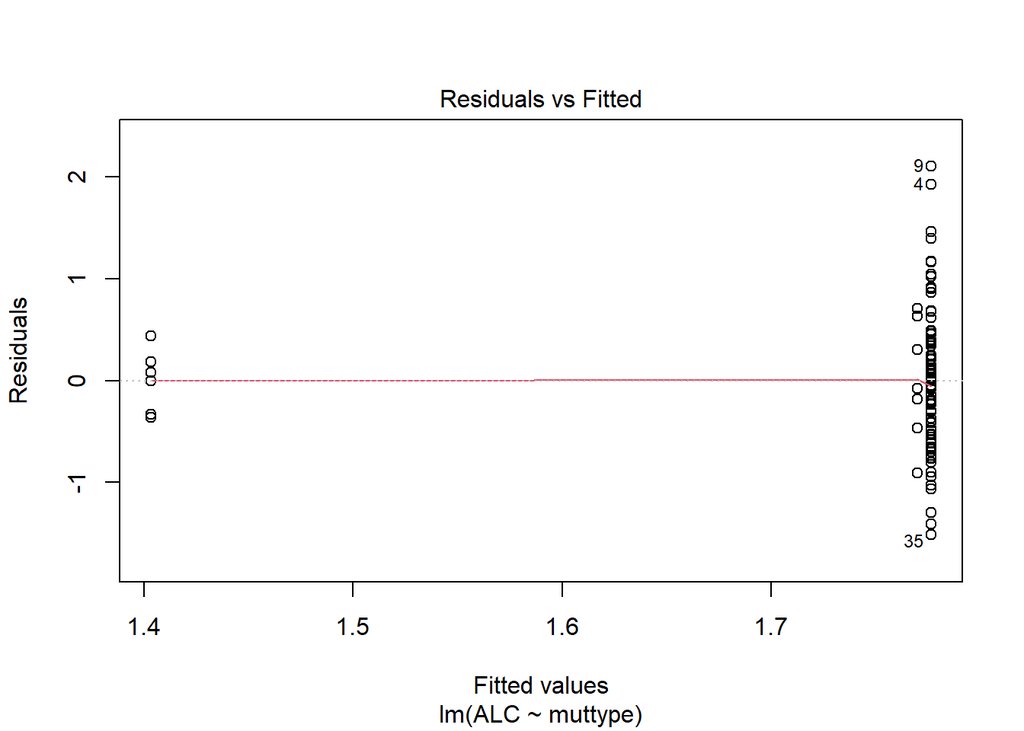

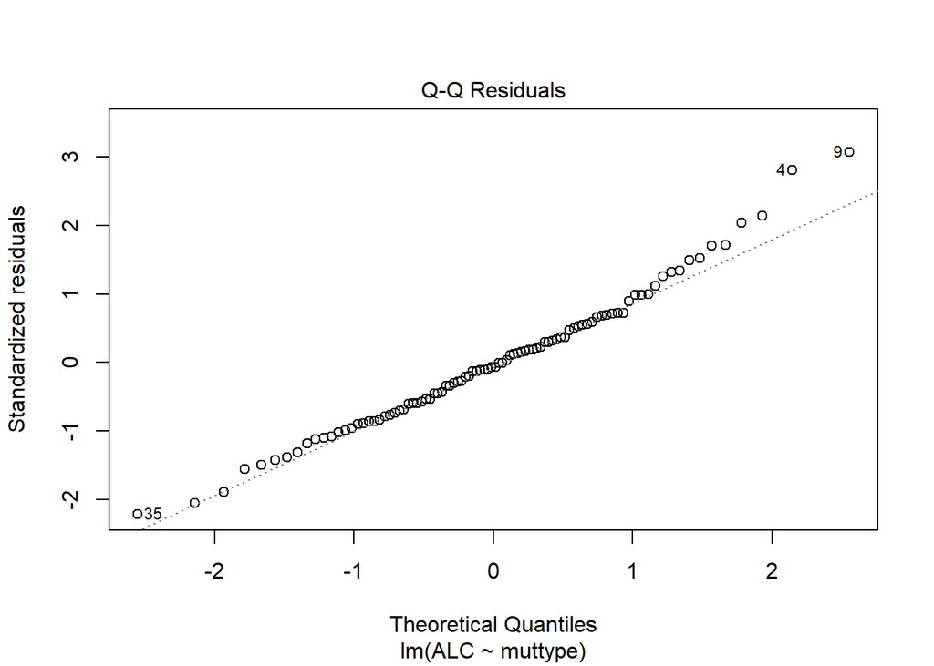

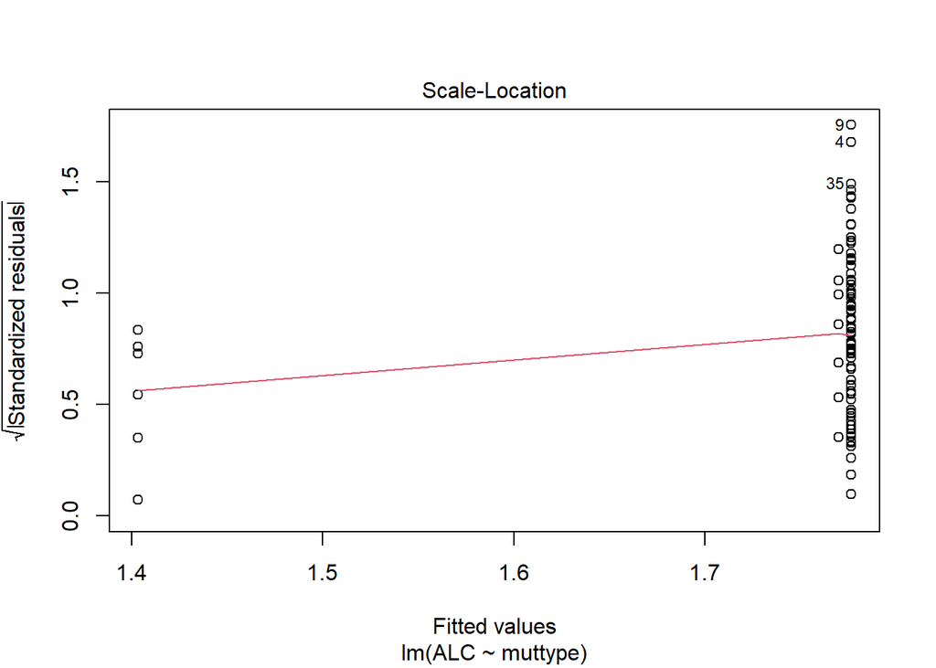

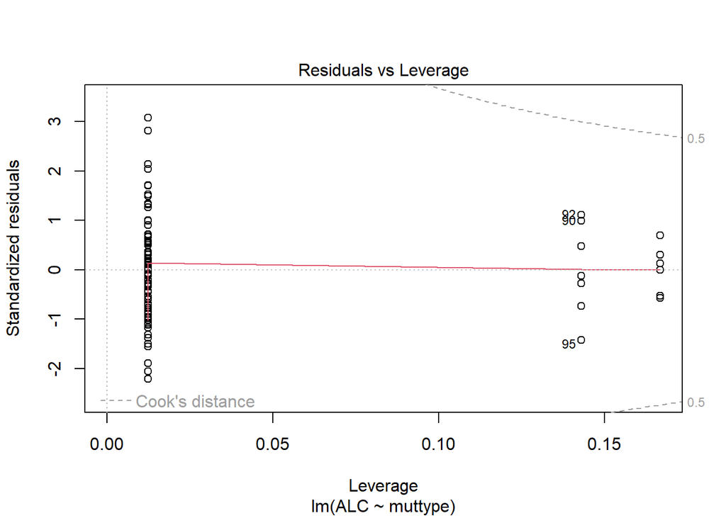

```r
modalc<- lm(ALC~muttype, data = RA3)
plot(modalc)
```

nonequal variance, so welch’s anova

```r
RA3 %>% welch_anova_test(ALC~muttype)
```

```
## # A tibble: 1 × 7
##   .y.       n statistic   DFn   DFd     p method
## * <chr> <int>     <dbl> <dbl> <dbl> <dbl> <chr>
## 1 ALC      96      3.05     2  10.6  0.09 Welch ANOVA
```

```r
RA4 %>% welch_anova_test(ALC~muttypelow)
```

```
## # A tibble: 1 × 7
##   .y.       n statistic   DFn   DFd     p method
## * <chr> <int>     <dbl> <dbl> <dbl> <dbl> <chr>
## 1 ALC      84    0.0062     2  24.5 0.994 Welch ANOVA
```

```r
#for making a dataset that can be put together for a later excel file

welch <-
  RA3 %>% welch_anova_test(ALC~muttype) %>%
  rbind(welch)

welch008 <-
  RA4 %>% welch_anova_test(ALC~muttypelow) %>%
  rbind(welch008)


#for making a csv that can be read in excel

#RA4 %>% welch_anova_test(ALC~muttypelow)%>%
#  write_csv(file = "welch.csv", append = TRUE)
```

### ANC anova

> both variance and normality did not seem to be met, so ran welch and kruskal wallis, neither was significant, put welch in dataset because variance seemed worse than normality

Make a box plot

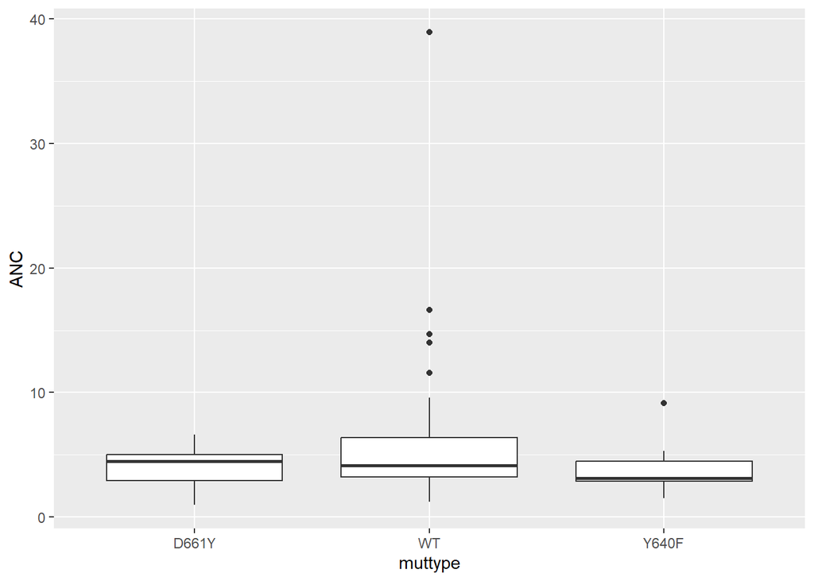

```r
RA3 %>% ggplot(aes(muttype, ANC))+geom_boxplot()
```

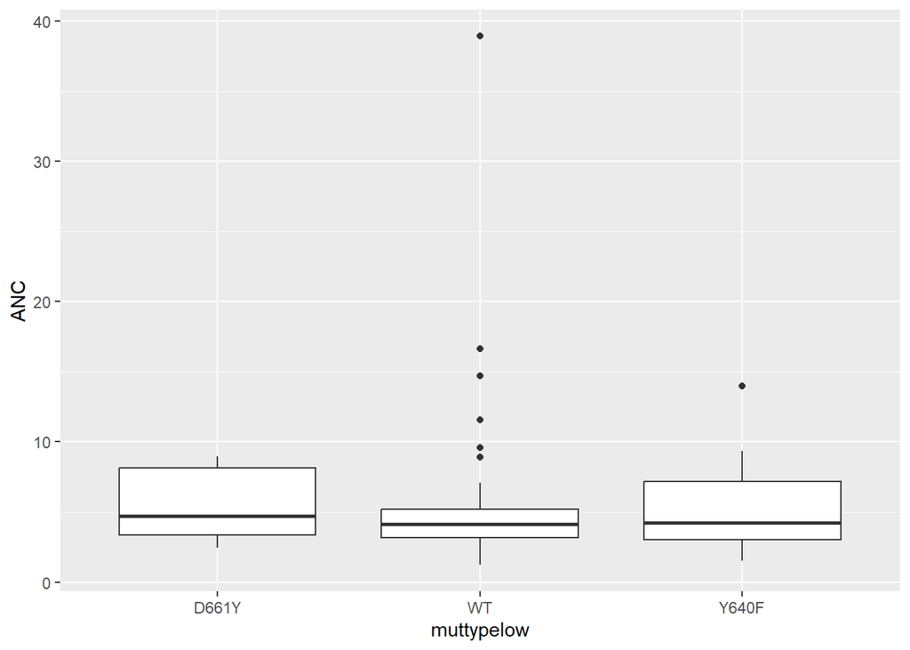

```r
RA4 %>% ggplot(aes(muttypelow, ANC))+geom_boxplot()
```

Run anova in order to test assumptions based on first plot, don’t have equal variance based on second plot, normality is also not met ignore the 4th plot

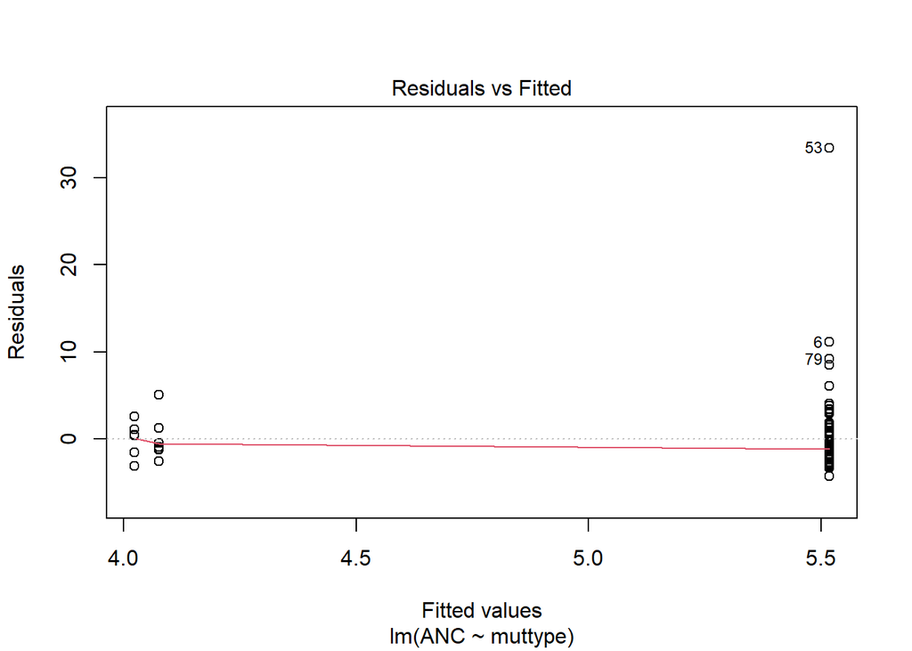

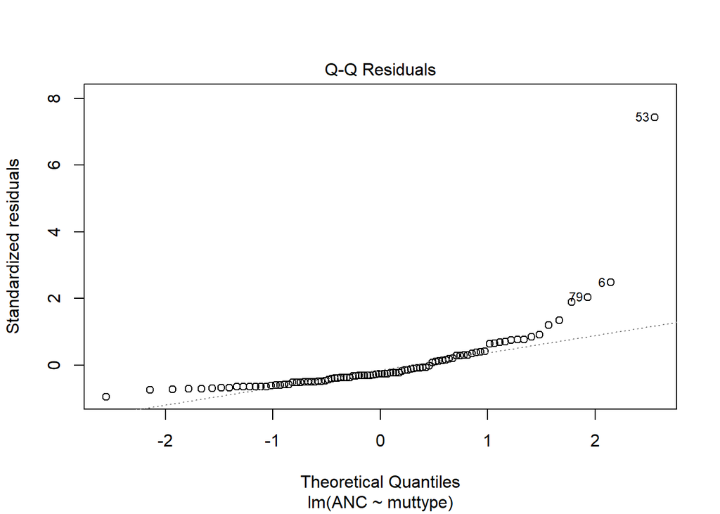

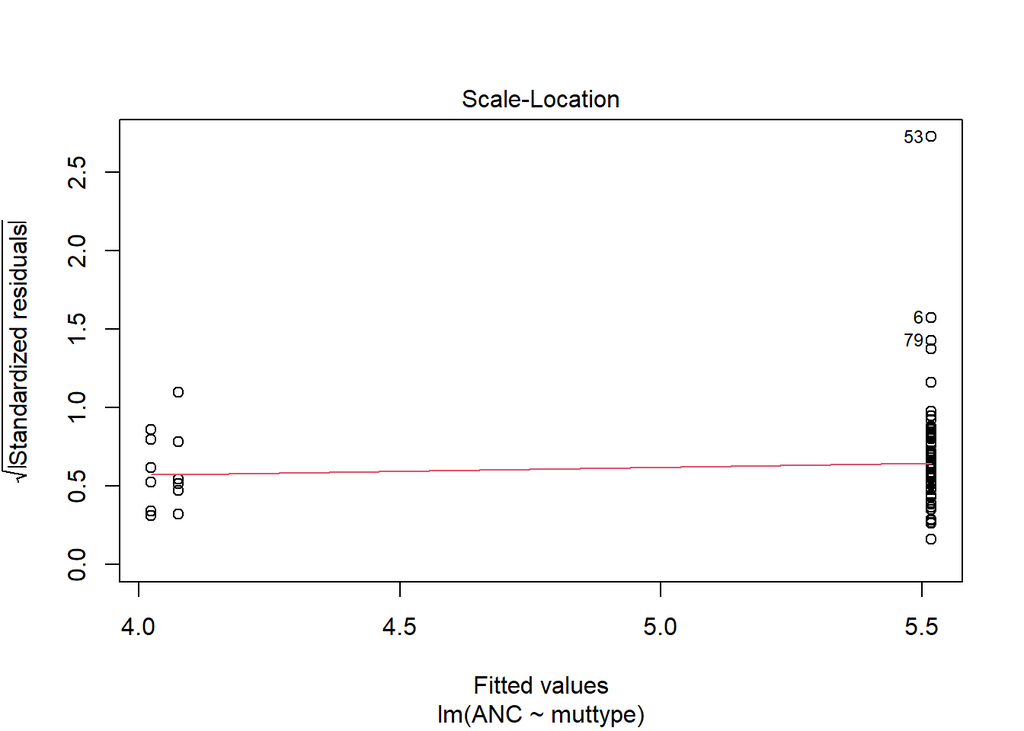

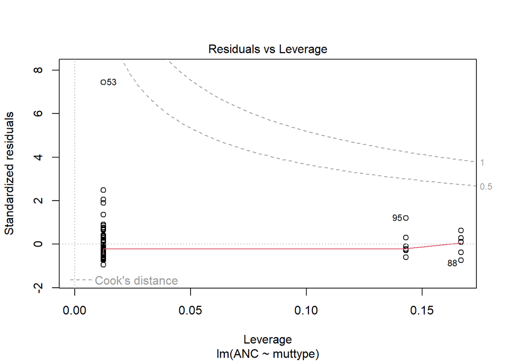

```r
modanc<- lm(ANC~muttype, data = RA3)
plot(modanc)
```

nonequal variance, so welch’s anova normality also bad, so also kruskal

```r
RA3 %>% welch_anova_test(ANC~muttype)
```

```
## # A tibble: 1 × 7
##   .y.       n statistic   DFn   DFd     p method
## * <chr> <int>     <dbl> <dbl> <dbl> <dbl> <chr>
## 1 ANC      96      1.55     2  11.6 0.254 Welch ANOVA
```

```r
RA3 %>% kruskal_test(ANC~muttype)
```

```
## # A tibble: 1 × 6
##   .y.       n statistic    df     p method
## * <chr> <int>     <dbl> <int> <dbl> <chr>
## 1 ANC      96      1.46     2 0.483 Kruskal-Wallis
```

```r
RA4 %>% welch_anova_test(ANC~muttypelow)
```

```
## # A tibble: 1 × 7
##   .y.       n statistic   DFn   DFd     p method
## * <chr> <int>     <dbl> <dbl> <dbl> <dbl> <chr>
## 1 ANC      84      0.05     2  31.7 0.956 Welch ANOVA
```

```r
RA4 %>% kruskal_test(ANC~muttypelow)
```

```
## # A tibble: 1 × 6
##   .y.       n statistic    df     p method
## * <chr> <int>     <dbl> <int> <dbl> <chr>
## 1 ANC      84     0.681     2 0.712 Kruskal-Wallis
```

```r
#making a dataset
welch <-
  RA3 %>% welch_anova_test(ANC~muttype) %>%
  rbind(welch)

welch008 <-
  RA4 %>% welch_anova_test(ANC~muttypelow) %>%
  rbind(welch008)
```

### txnum anova

> unequal variance, used welch’s anova, no significance

Make a box plot

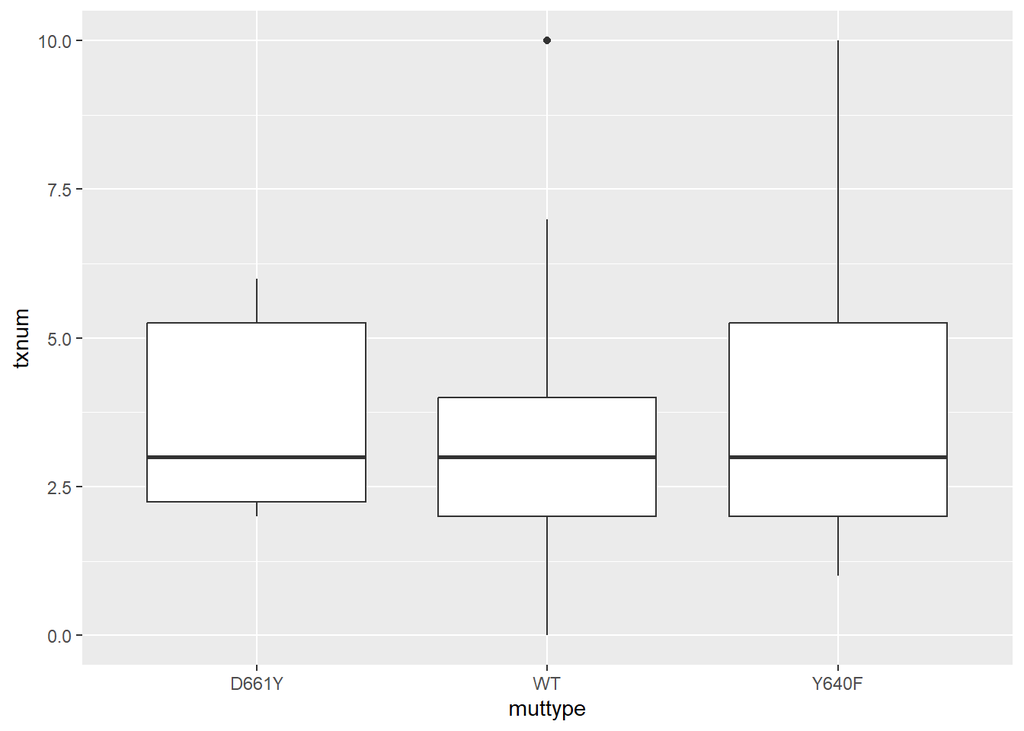

```r
RA3 %>% ggplot(aes(muttype, txnum))+geom_boxplot()
```

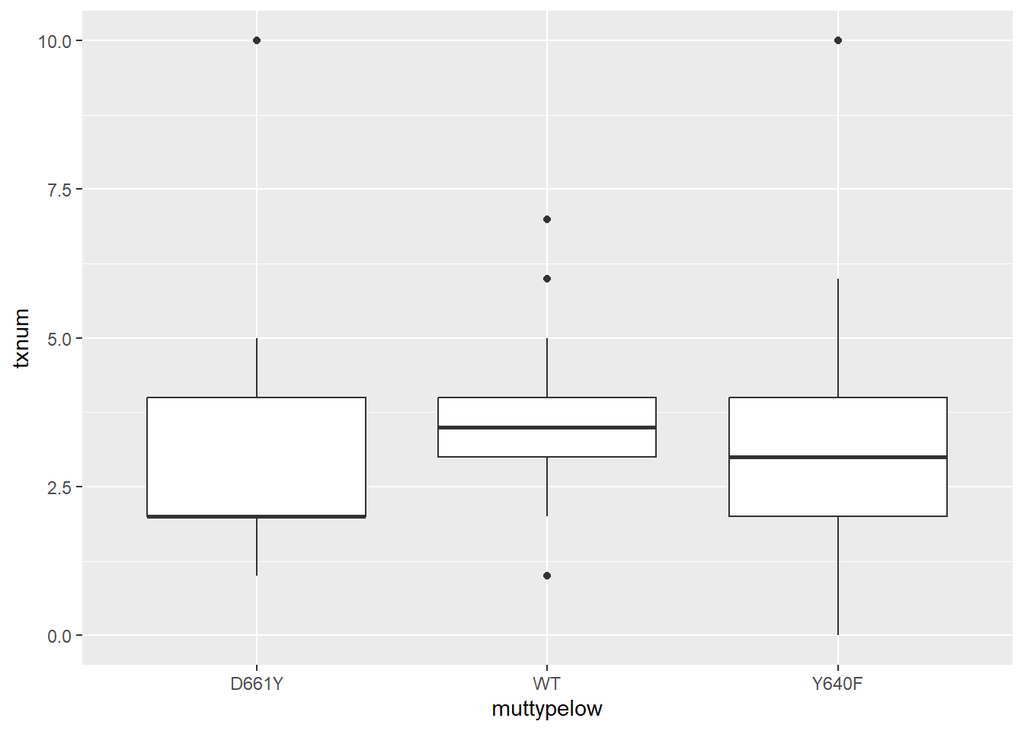

```r
RA4 %>% ggplot(aes(muttypelow, txnum))+geom_boxplot()
```

Run anova in order to test assumptions based on first plot, don’t have equal variance based on second plot, normality is met ignore the 4th plot

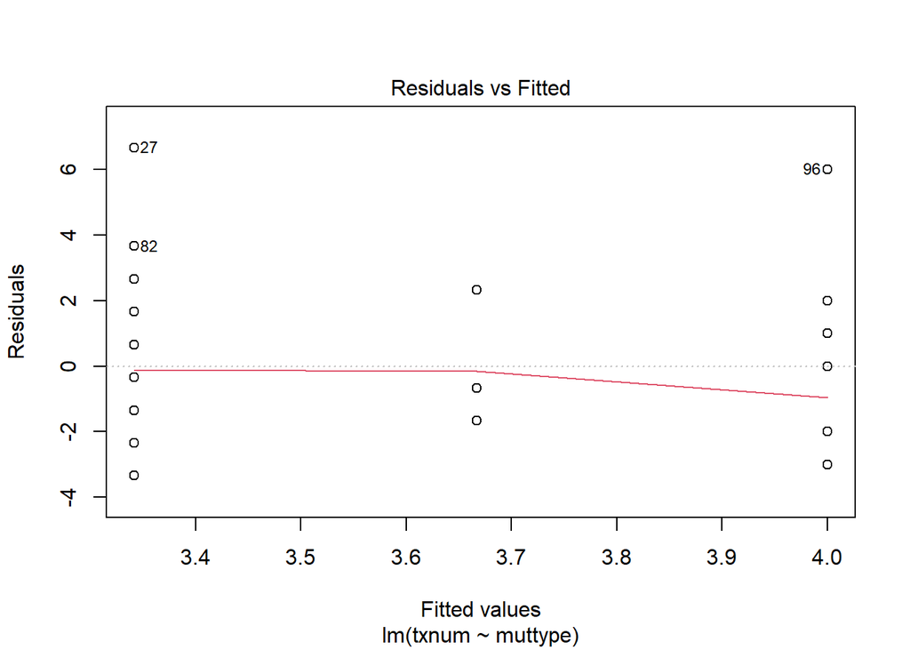

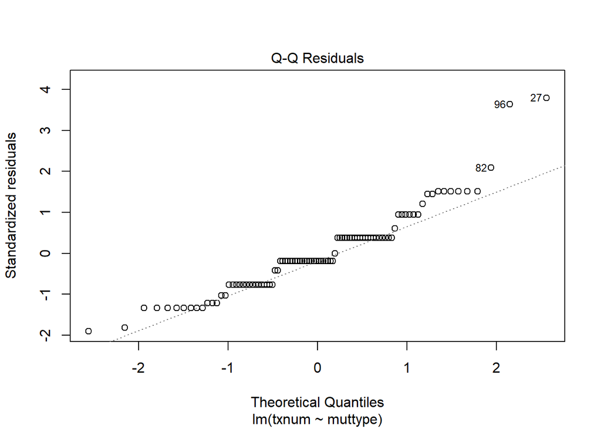

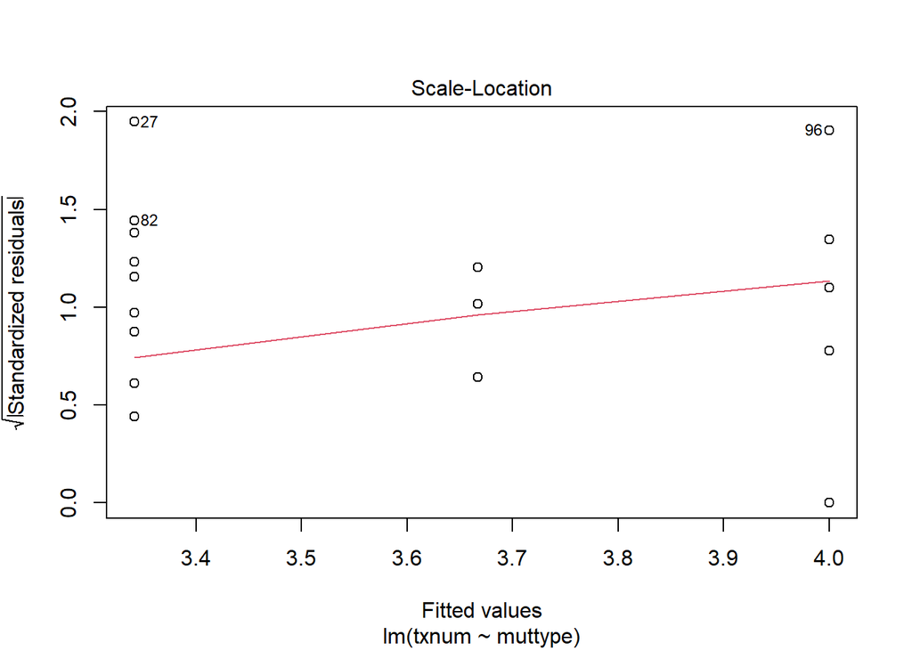

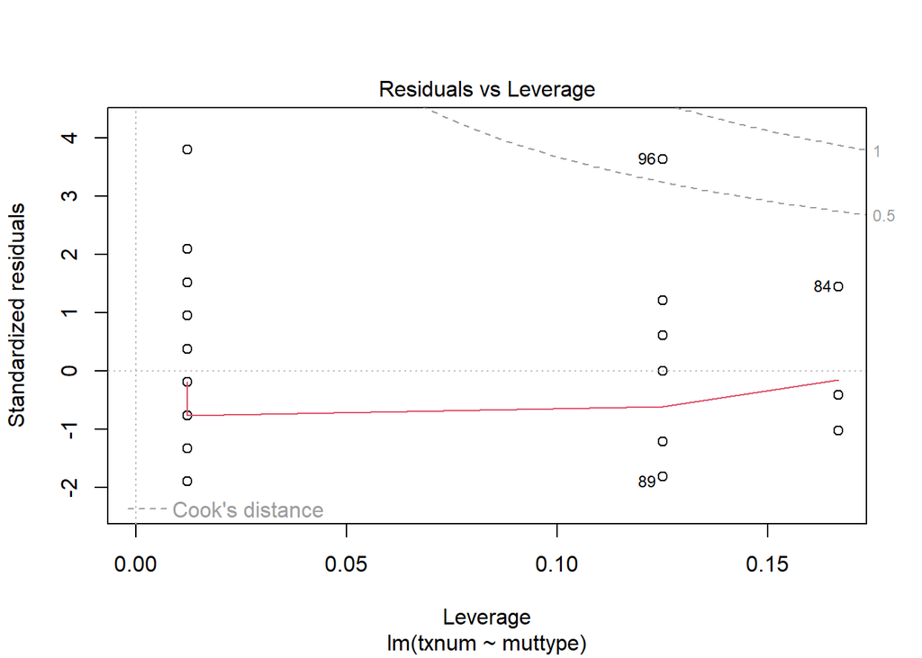

```r
mod<- lm(txnum~muttype, data = RA3)
plot(mod)
```

nonequal variance, so welch’s anova

```r
RA3 %>% welch_anova_test(txnum~muttype)
```

```
## # A tibble: 1 × 7
##   .y.       n statistic   DFn   DFd     p method
## * <chr> <int>     <dbl> <dbl> <dbl> <dbl> <chr>
## 1 txnum    96      0.25     2  8.45 0.786 Welch ANOVA
```

```r
RA4 %>% welch_anova_test(txnum~muttypelow)
```

```
## # A tibble: 1 × 7
##   .y.       n statistic   DFn   DFd     p method
## * <chr> <int>     <dbl> <dbl> <dbl> <dbl> <chr>
## 1 txnum    84      0.39     2  23.3 0.681 Welch ANOVA
```

```r
#making a dataset

welch <-
  RA3 %>% welch_anova_test(txnum~muttype) %>%
  rbind(welch)

welch008 <-
  RA4 %>% welch_anova_test(txnum~muttypelow) %>%
  rbind(welch008)
```